# Home credit risk

# Factor Variables

```r
#factorizing  character variables for use of data effectively
train_data$NAME_CONTRACT_TYPE <- factor(train_data$NAME_CONTRACT_TYPE)
train_data$CODE_GENDER <- factor(train_data$CODE_GENDER)
train_data$FLAG_OWN_CAR <- factor(train_data$FLAG_OWN_CAR)
train_data$FLAG_OWN_REALTY <- factor(train_data$FLAG_OWN_REALTY )
train_data$NAME_TYPE_SUITE <- factor(train_data$NAME_TYPE_SUITE)
train_data$NAME_INCOME_TYPE <- factor(train_data$NAME_INCOME_TYPE)
train_data$NAME_EDUCATION_TYPE <- factor(train_data$NAME_EDUCATION_TYPE)
train_data$NAME_FAMILY_STATUS <- factor(train_data$NAME_FAMILY_STATUS)
train_data$NAME_HOUSING_TYPE <- factor(train_data$NAME_HOUSING_TYPE )
train_data$OCCUPATION_TYPE <- factor(train_data$OCCUPATION_TYPE)
train_data$WEEKDAY_APPR_PROCESS_START <- factor(train_data$WEEKDAY_APPR_PROCESS_START)
train_data$ORGANIZATION_TYPE <- factor(train_data$ORGANIZATION_TYPE)
train_data$FONDKAPREMONT_MODE <- factor(train_data$FONDKAPREMONT_MODE)
train_data$HOUSETYPE_MODE <- factor(train_data$HOUSETYPE_MODE)
train_data$WALLSMATERIAL_MODE <- factor(train_data$WALLSMATERIAL_MODE)
train_data$EMERGENCYSTATE_MODE <- factor(train_data$EMERGENCYSTATE_MODE)
```

## Structure & Summary after Factorization

```r
train_data %>% str()
```

```
## 'data.frame':    307511 obs. of  77 variables:
##  $ SK_ID_CURR                 : int  100002 100003 100004 100006 100007 100008 100009 100010 100011 100012 ...
##  $ TARGET                     : int  1 0 0 0 0 0 0 0 0 0 ...
##  $ NAME_CONTRACT_TYPE         : Factor w/ 2 levels "Cash loans","Revolving loans": 1 1 2 1 1 1 1 1 1 2 ...
##  $ CODE_GENDER                : Factor w/ 3 levels "F","M","XNA": 2 1 2 1 2 2 1 2 1 2 ...
##  $ FLAG_OWN_CAR               : Factor w/ 2 levels "N","Y": 1 1 2 1 1 1 2 2 1 1 ...
##  $ FLAG_OWN_REALTY            : Factor w/ 2 levels "N","Y": 2 1 2 2 2 2 2 2 2 2 ...
##  $ CNT_CHILDREN               : int  0 0 0 0 0 0 1 0 0 0 ...
##  $ AMT_INCOME_TOTAL           : num  202500 270000 67500 135000 121500 ...
##  $ AMT_CREDIT                 : num  406598 1293503 135000 312683 513000 ...
##  $ AMT_ANNUITY                : num  24701 35699 6750 29687 21866 ...
##  $ AMT_GOODS_PRICE            : num  351000 1129500 135000 297000 513000 ...
##  $ NAME_TYPE_SUITE            : Factor w/ 8 levels "","Children",..: 8 3 8 8 8 7 8 8 2 8 ...
##  $ NAME_INCOME_TYPE           : Factor w/ 8 levels "Businessman",..: 8 5 8 8 8 5 2 5 4 8 ...
##  $ NAME_EDUCATION_TYPE        : Factor w/ 5 levels "Academic degree",..: 5 2 5 5 5 5 2 2 5 5 ...
```

[output cut: 63 more lines]

```r
train_data %>% summary()
```

```
##    SK_ID_CURR         TARGET              NAME_CONTRACT_TYPE CODE_GENDER
##  Min.   :100002   Min.   :0.00000   Cash loans     :278232   F  :202448
##  1st Qu.:189146   1st Qu.:0.00000   Revolving loans: 29279   M  :105059
##  Median :278202   Median :0.00000                            XNA:     4
##  Mean   :278181   Mean   :0.08073
##  3rd Qu.:367143   3rd Qu.:0.00000
##  Max.   :456255   Max.   :1.00000
##
##  FLAG_OWN_CAR FLAG_OWN_REALTY  CNT_CHILDREN     AMT_INCOME_TOTAL
##  N:202924     N: 94199        Min.   : 0.0000   Min.   :    25650
##  Y:104587     Y:213312        1st Qu.: 0.0000   1st Qu.:   112500
##                               Median : 0.0000   Median :   147150
##                               Mean   : 0.4171   Mean   :   168798
##                               3rd Qu.: 1.0000   3rd Qu.:   202500
##                               Max.   :19.0000   Max.   :117000000
##
##    AMT_CREDIT       AMT_ANNUITY     AMT_GOODS_PRICE          NAME_TYPE_SUITE
##  Min.   :  45000   Min.   :  1616   Min.   :  40500   Unaccompanied  :248526
##  1st Qu.: 270000   1st Qu.: 16524   1st Qu.: 238500   Family         : 40149
##  Median : 513531   Median : 24903   Median : 450000   Spouse, partner: 11370
##  Mean   : 599026   Mean   : 27109   Mean   : 538396   Children       :  3267
##  3rd Qu.: 808650   3rd Qu.: 34596   3rd Qu.: 679500   Other_B        :  1770
##  Max.   :4050000   Max.   :258026   Max.   :4050000                  :  1292
##                    NA's   :12       NA's   :278       (Other)        :  1137
##              NAME_INCOME_TYPE                     NAME_EDUCATION_TYPE
##  Working             :158774   Academic degree              :   164
##  Commercial associate: 71617   Higher education             : 74863
##  Pensioner           : 55362   Incomplete higher            : 10277
##  State servant       : 21703   Lower secondary              :  3816
##  Unemployed          :    22   Secondary / secondary special:218391
##  Student             :    18
##  (Other)             :    15
##             NAME_FAMILY_STATUS           NAME_HOUSING_TYPE
##  Civil marriage      : 29775   Co-op apartment    :  1122
##  Married             :196432   House / apartment  :272868
##  Separated           : 19770   Municipal apartment: 11183
##  Single / not married: 45444   Office apartment   :  2617
##  Unknown             :     2   Rented apartment   :  4881
##  Widow               : 16088   With parents       : 14840
##
```

[output cut: 137 more lines]

```
##  Min.   :0.00               Min.   : 0.00             Min.   :  0.00
##  1st Qu.:0.00               1st Qu.: 0.00             1st Qu.:  0.00
##  Median :0.00               Median : 0.00             Median :  0.00
##  Mean   :0.03               Mean   : 0.27             Mean   :  0.27
##  3rd Qu.:0.00               3rd Qu.: 0.00             3rd Qu.:  0.00
##  Max.   :8.00               Max.   :27.00             Max.   :261.00
##  NA's   :41519              NA's   :41519             NA's   :41519
##  AMT_REQ_CREDIT_BUREAU_YEAR
##  Min.   : 0.0
##  1st Qu.: 0.0
##  Median : 1.0
##  Mean   : 1.9
##  3rd Qu.: 3.0
##  Max.   :25.0
##  NA's   :41519
```

## Exploring target variable

```r
#Exploring the target variable
target_0 <- train_data %>%
  dplyr::summarize(TARGET = mean(TARGET =="0"))
target_1 <- train_data %>%
  dplyr::summarize(TARGET = mean(TARGET =="1"))
print(target_0)
```

```
##      TARGET
## 1 0.9192712
```

```r
print(target_1)
```

```
##       TARGET
## 1 0.08072882
```

The above analysis of the target variable shows two values, “0” and “1.” which shows that : value “0” means that the client had no difficulty repaying the loan he took value “1” indicates that the client has faced difficulty repaying the loan As we can see, about 91.92% of the people faced no difficulty repaying the loan, while 8.07% faced trouble repaying the loan.

## Factorizing target variable

```r
# as target variable is binary we are factorizing it to see count in each category
train_data$TARGET <- factor(train_data$TARGET )

train_data$TARGET %>% str()
```

```
##  Factor w/ 2 levels "0","1": 2 1 1 1 1 1 1 1 1 1 ...
```

```r
train_data$TARGET %>% summary()
```

```
##      0      1
## 282686  24825
```

# Visualisations

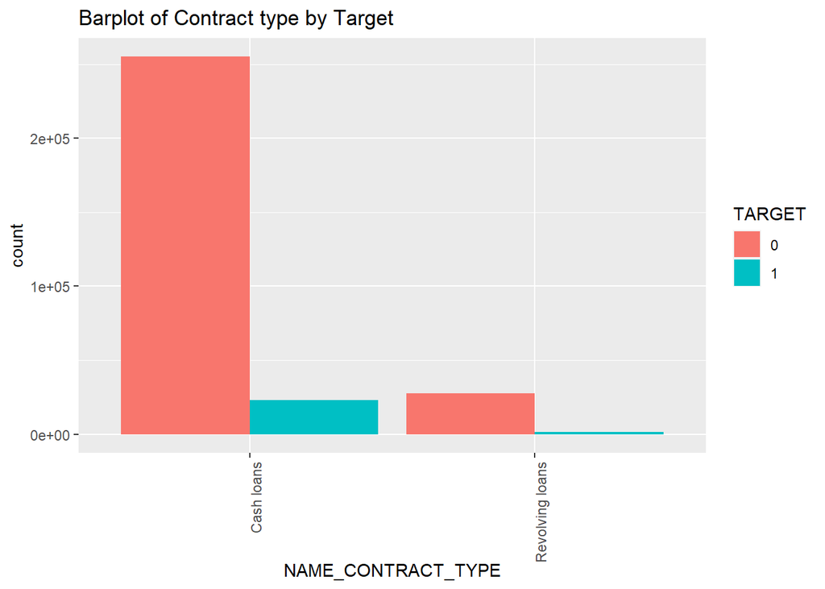

```r
#Bar graph of name contract type w.r.t Target
train_data %>% ggplot() +
  geom_bar(aes(x= NAME_CONTRACT_TYPE,fill=TARGET), position="dodge") +
  ggtitle("Barplot of Contract type by Target")+
theme(axis.text.x = element_text(angle = 90, hjust = 1))
```

In the above bar plot, we can see that most of the clients chose the cash loan option as they are loan options rather than revolving loans and were able to pay the loan back with no difficulty. However, compared to revolving loans, cash loans have more people who faced trouble paying back the loan.

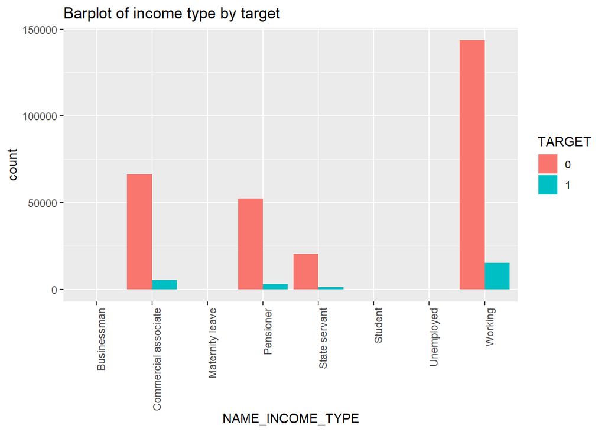

```r
#Bar graph of name_income_type type w.r.t Target
train_data %>% ggplot() +
  geom_bar(aes(x= NAME_INCOME_TYPE,fill=TARGET), position="dodge") +
  ggtitle("Barplot of income type by target")+
theme(axis.text.x = element_text(angle = 90, hjust = 1))
```

We can see that the clients with income types such as working have a higher rate of taking loans from the bank, and also, most of them have paid back the loans with no difficulty. Commercial associates come in second place, with most people repaying the loan without difficulty.

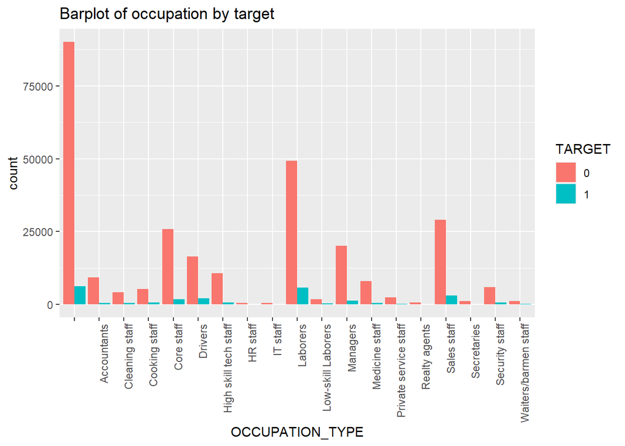

```r
#Bar graph of Occupation type w.r.t Target
train_data %>% ggplot() +
  geom_bar(aes(x= OCCUPATION_TYPE,fill=TARGET), position="dodge") +
  ggtitle("Barplot of occupation by target")+
theme(axis.text.x = element_text(angle = 90, hjust = 1))
```

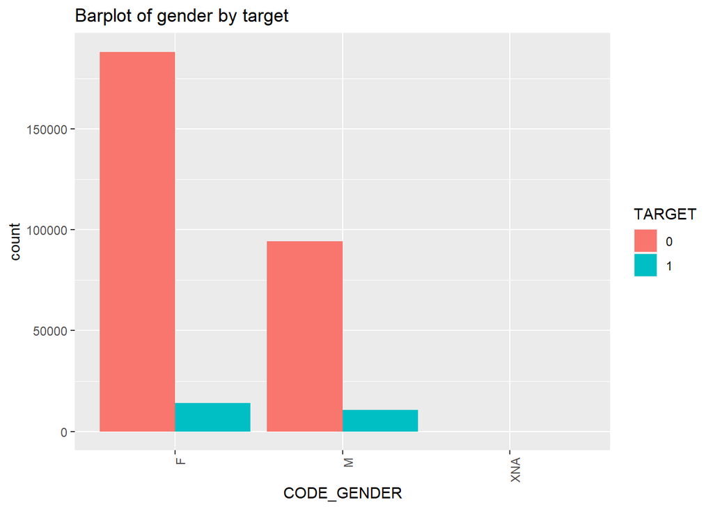

```r
#Bar graph of CODE_GENDER w.r.t Target
train_data %>% ggplot() +
  geom_bar(aes(x= CODE_GENDER,fill=TARGET), position="dodge") +
  ggtitle("Barplot of gender by target")+
theme(axis.text.x = element_text(angle = 90, hjust = 1))
```

The above graph shows that females have a higher rate of taking loans from the bank and repaying the loans with no difficulty compared to men, while the number of men taking loans from the banks is less than that of females.